# Joining_Datasets

Alvaro Guijarro

2024-02-29

This R script is used to clean and structure the Population Data for later analytical use. The data was adquired from DANE.

```r
# Load libraries
library(readxl)
library(writexl)
library(dplyr)
```

```r
library(ggplot2)
setwd("C:/Users/alvar/OneDrive/Documents/GitHub/Hertie_School_MDS_Master_Thesis")
```

```r
# Use file.choose() to interactively select the Excel files
file_path1 <- file.choose() #DCD-area-proypoblacion-Mun-2020-2035-ActPostCOVID-19
file_path2 <- file.choose() #DCD-area-proypoblacion-Mun-2005-2019
file_path3 <- file.choose() #Ciudades y sus Areas Metropolitanas en GEIH (to standarize names)

# Read the selected Excel files
data_2020_2035 <- read_excel(file_path1)
data_2005_2019 <- read_excel(file_path2)
official_city_names <- read_excel(file_path3)
```

Let’s identify which are the cities we are going to join our population database with our worker’s database

```r
# Filter the dataset for rows where the "Tipo" column is "principal"
main_cities <- official_city_names %>%
  filter(Tipo == "principal")
main_cities
```

```
## # A tibble: 13 × 7
##    municipio     ciudad_am   region cod_dane_dep departamento cod_dane_mun Tipo
##    <chr>         <chr>       <chr>         <dbl> <chr>               <dbl> <chr>
##  1 Barranquilla  BARRANQUIL… Regió…            8 Atlántico            8001 prin…
##  2 Bogotá D.C.   BOGOTÁ D.C. Regió…           11 Bogotá D.C.         11001 prin…
##  3 Bucaramanga   BUCARAMANG… Regió…           68 Santander           68001 prin…
##  4 Cali          CALI  A.M.  Regió…           76 Valle del C…        76001 prin…
##  5 Cartagena     CARTAGENA   Regió…           13 Bolívar             13001 prin…
##  6 Cúcuta        CÚCUTA A.M. Regió…           54 Norte de Sa…        54001 prin…
##  7 Ibagué        IBAGUÉ      Regió…           73 Tolima              73001 prin…
##  8 Manizales     MANIZALES … Regió…           17 Caldas              17001 prin…
##  9 Medellín      MEDELLÍN A… Regió…            5 Antioquia            5001 prin…
## 10 Montería      MONTERÍA    Regió…           23 Córdoba             23001 prin…
## 11 Pasto         PASTO       Regió…           52 Nariño              52001 prin…
## 12 Pereira       PEREIRA A.… Regió…           66 Risaralda           66001 prin…
## 13 Villavicencio VILLAVICEN… Regió…           50 Meta                50001 prin…
```

```r
# Display the first 10 rows of the first document
head(data_2020_2035, n = 10)
```

```
## # A tibble: 10 × 7
##    ACTUALIZACIÓN POST COVID-19. PROYECCION…¹ ...2  ...3  ...4  ...5  ...6  ...7
##    <chr>                                     <chr> <chr> <chr> <chr> <chr> <chr>
##  1 <NA>                                      <NA>  <NA>  <NA>  <NA>  <NA>  <NA>
##  2 PROYECCIONES DE POBLACIÓN A NIVEL MUNICI… <NA>  <NA>  <NA>  <NA>  <NA>  <NA>
##  3 <NA>                                      <NA>  <NA>  <NA>  <NA>  <NA>  <NA>
##  4 <NA>                                      <NA>  <NA>  <NA>  <NA>  <NA>  <NA>
##  5 <NA>                                      <NA>  <NA>  <NA>  <NA>  <NA>  <NA>
##  6 DP                                        DPNOM MPIO  DPMP  AÑO   ÁREA… Pobl…
##  7 05                                        Anti… 05001 Mede… 2020  Cabe… 2476…
##  8 05                                        Anti… 05001 Mede… 2020  Cent… 43023
##  9 05                                        Anti… 05001 Mede… 2020  Total 2519…
## 10 05                                        Anti… 05001 Mede… 2021  Cabe… 2506…
## # ℹ abbreviated name:
## #   ¹`ACTUALIZACIÓN POST COVID-19. PROYECCIONES DE POBLACIÓN MUNICIPAL POR ÁREA.`
```

```r
summary(data_2020_2035)
```

```
##  ACTUALIZACIÓN POST COVID-19. PROYECCIONES DE POBLACIÓN MUNICIPAL POR ÁREA.
##  Length:53865
##  Class :character
##  Mode  :character
##      ...2               ...3               ...4               ...5
##  Length:53865       Length:53865       Length:53865       Length:53865
##  Class :character   Class :character   Class :character   Class :character
##  Mode  :character   Mode  :character   Mode  :character   Mode  :character
##      ...6               ...7
##  Length:53865       Length:53865
##  Class :character   Class :character
##  Mode  :character   Mode  :character
```

```r
# Display the first 10 rows of the second document
head(data_2005_2019, n = 10)
```

```
## # A tibble: 10 × 7
##    PROYECCIONES DE POBLACIÓN MUNICIPAL POR…¹ ...2  ...3  ...4  ...5  ...6  ...7
##    <chr>                                     <chr> <chr> <chr> <chr> <chr> <chr>
##  1 <NA>                                      <NA>  <NA>  <NA>  <NA>  <NA>  <NA>
##  2 PROYECCIONES DE POBLACIÓN A NIVEL MUNICI… <NA>  <NA>  <NA>  <NA>  <NA>  <NA>
##  3 <NA>                                      <NA>  <NA>  <NA>  <NA>  <NA>  <NA>
##  4 <NA>                                      <NA>  <NA>  <NA>  <NA>  <NA>  <NA>
##  5 <NA>                                      <NA>  <NA>  <NA>  <NA>  <NA>  <NA>
##  6 DP                                        DPNOM DPMP  MPIO  AÑO   ÁREA… Pobl…
##  7 05                                        Anti… Mede… 05001 2005  Cabe… 1997…
##  8 05                                        Anti… Mede… 05001 2005  Cent… 48578
##  9 05                                        Anti… Mede… 05001 2005  Total 2046…
## 10 05                                        Anti… Abej… 05002 2005  Cabe… 7158
## # ℹ abbreviated name: ¹`PROYECCIONES DE POBLACIÓN MUNICIPAL POR ÁREA.`
```

```r
summary(data_2005_2019)
```

```
##  PROYECCIONES DE POBLACIÓN MUNICIPAL POR ÁREA.     ...2
##  Length:50496                                  Length:50496
##  Class :character                              Class :character
##  Mode  :character                              Mode  :character
##      ...3               ...4               ...5               ...6
##  Length:50496       Length:50496       Length:50496       Length:50496
##  Class :character   Class :character   Class :character   Class :character
##  Mode  :character   Mode  :character   Mode  :character   Mode  :character
##      ...7
##  Length:50496
##  Class :character
##  Mode  :character
```

Let’s proceed to clean the first dataset, data_2020_2035.

```r
# Set the names of the dataset's columns to the values in row 6
col_names <- data_2020_2035[6, ] # Get the 6th row to use as column names
names(data_2020_2035) <- col_names # Set the column names
# Delete the first 6 rows of the document
data_2020_2035_c <- data_2020_2035[-(1:6), ]

# Filter by column "ÁREA GEOGRÁFICA" for rows that contain "Total"
data_2020_2035_c <- data_2020_2035_c[data_2020_2035_c$`ÁREA GEOGRÁFICA` == "Total", ]

# Convert to a data frame if it's not already (since we may have a tibble or similar)
data_2020_2035_c <- as.data.frame(data_2020_2035_c)

# Set variable types
data_2020_2035_c$AÑO <- as.integer(data_2020_2035_c$AÑO)
data_2020_2035_c$Población <- as.integer(data_2020_2035_c$Población)

# Reset row numbering
rownames(data_2020_2035_c) <- NULL

# View the cleaned dataset
head(data_2020_2035_c)
```

```
##   DP     DPNOM  MPIO     DPMP  AÑO ÁREA GEOGRÁFICA Población
## 1 05 Antioquia 05001 Medellín 2020           Total   2519592
## 2 05 Antioquia 05001 Medellín 2021           Total   2549008
## 3 05 Antioquia 05001 Medellín 2022           Total   2572350
## 4 05 Antioquia 05001 Medellín 2023           Total   2595300
## 5 05 Antioquia 05001 Medellín 2024           Total   2616335
## 6 05 Antioquia 05001 Medellín 2025           Total   2634570
```

Let’s join the information from this dataset with “main_cities” to get the same name format and ID of the cities from our workers main database.

```r
# Ensure that cod_dane_mun is character so that we can add leading zeroes
main_cities$cod_dane_mun <- sprintf("%05d", as.integer(main_cities$cod_dane_mun))

# Ensure that MPIO is also character for consistency before the join
data_2020_2035_c$MPIO <- as.character(data_2020_2035_c$MPIO)

# Perform the inner join
data_2020_2035_c_joined <- inner_join(data_2020_2035_c, main_cities, by = c("MPIO" = "cod_dane_mun"))

# Now, filter the dataset to only include rows with "principal" or non-NA in the "Tipo" column
data_2020_2035_c_joined <- data_2020_2035_c_joined %>%
  filter(!is.na(Tipo) & Tipo == "principal")

# View the first few rows of the joined and filtered dataset
unique(data_2020_2035_c_joined$ciudad_am)
```

```
##  [1] "MEDELLÍN A.M."     "BARRANQUILLA A.M." "BOGOTÁ D.C."
##  [4] "CARTAGENA"         "MANIZALES A.M."    "MONTERÍA"
##  [7] "VILLAVICENCIO"     "PASTO"             "CÚCUTA A.M."
## [10] "PEREIRA A.M."      "BUCARAMANGA A.M."  "IBAGUÉ"
## [13] "CALI  A.M."
```

```r
names(data_2020_2035_c_joined)
```

```
##  [1] "DP"              "DPNOM"           "MPIO"            "DPMP"
##  [5] "AÑO"             "ÁREA GEOGRÁFICA" "Población"       "municipio"
##  [9] "ciudad_am"       "region"          "cod_dane_dep"    "departamento"
## [13] "Tipo"
```

Now let’s do the same with the “2005_2019” dataset.

```r
# Set the names of the dataset's columns to the values in row 6
col_names_2 <- data_2005_2019[6, ] # Get the 6th row to use as column names
names(data_2005_2019) <- col_names_2 # Set the column names

# Delete the first 6 rows of the document
data_2005_2019_c <- data_2005_2019[-(1:6), ]

# Filter by column "ÁREA GEOGRÁFICA" for rows that contain "Total"
data_2005_2019_c <- data_2005_2019_c[data_2005_2019_c$`ÁREA GEOGRÁFICA` == "Total", ]

# Convert to a data frame if it's not already (since we may have a tibble or similar)
data_2005_2019_c <- as.data.frame(data_2005_2019_c)

# Set variable types
data_2005_2019_c$AÑO <- as.integer(data_2005_2019_c$AÑO)
data_2005_2019_c$Población <- as.integer(data_2005_2019_c$Población)

# Reset row numbering
rownames(data_2005_2019_c) <- NULL

# View the cleaned dataset
head(data_2005_2019_c)
```

```
##   DP     DPNOM       DPMP  MPIO  AÑO ÁREA GEOGRÁFICA Población
## 1 05 Antioquia   Medellín 05001 2005           Total   2046341
## 2 05 Antioquia  Abejorral 05002 2005           Total     22942
## 3 05 Antioquia   Abriaquí 05004 2005           Total      2719
## 4 05 Antioquia Alejandría 05021 2005           Total      4724
## 5 05 Antioquia      Amagá 05030 2005           Total     27121
## 6 05 Antioquia     Amalfi 05031 2005           Total     22933
```

Let’s join the information from this dataset with “main_cities” to get the same name format and ID of the cities from our workers main database.

```r
# Ensure that MPIO is also character for consistency before the join
data_2005_2019_c$MPIO <- as.character(data_2005_2019_c$MPIO)

# Perform the inner join
data_2005_2019_c_joined <- inner_join(data_2005_2019_c, main_cities, by = c("MPIO" = "cod_dane_mun"))

# Now, filter the dataset to only include rows with "principal" or non-NA in the "Tipo" column
data_2005_2019_c_joined <- data_2005_2019_c_joined %>%
  filter(!is.na(Tipo) & Tipo == "principal")

# View the first few rows of the joined and filtered dataset
unique(data_2005_2019_c_joined$ciudad_am)
```

```
##  [1] "MEDELLÍN A.M."     "BARRANQUILLA A.M." "BOGOTÁ D.C."
##  [4] "CARTAGENA"         "MANIZALES A.M."    "MONTERÍA"
##  [7] "VILLAVICENCIO"     "PASTO"             "CÚCUTA A.M."
## [10] "PEREIRA A.M."      "BUCARAMANGA A.M."  "IBAGUÉ"
## [13] "CALI  A.M."
```

```r
names(data_2005_2019_c_joined)
```

```
##  [1] "DP"              "DPNOM"           "DPMP"            "MPIO"
##  [5] "AÑO"             "ÁREA GEOGRÁFICA" "Población"       "municipio"
##  [9] "ciudad_am"       "region"          "cod_dane_dep"    "departamento"
## [13] "Tipo"
```

Check that both datasets have the same columns and correct information.

```r
head(data_2005_2019_c_joined)
```

```
##   DP        DPNOM                DPMP  MPIO  AÑO ÁREA GEOGRÁFICA Población
## 1 05    Antioquia            Medellín 05001 2005           Total   2046341
## 2 08    Atlántico        Barranquilla 08001 2005           Total   1090935
## 3 11 Bogotá, D.C.        Bogotá, D.C. 11001 2005           Total   6710910
## 4 13      Bolívar Cartagena de Indias 13001 2005           Total    838757
## 5 17       Caldas           Manizales 17001 2005           Total    400148
## 6 23      Córdoba            Montería 23001 2005           Total    419219
##      municipio         ciudad_am                          region cod_dane_dep
## 1     Medellín     MEDELLÍN A.M. Región Eje Cafetero - Antioquia            5
## 2 Barranquilla BARRANQUILLA A.M.                   Región Caribe            8
## 3  Bogotá D.C.       BOGOTÁ D.C.           Región Centro Oriente           11
## 4    Cartagena         CARTAGENA                   Región Caribe           13
## 5    Manizales    MANIZALES A.M. Región Eje Cafetero - Antioquia           17
## 6     Montería          MONTERÍA                   Región Caribe           23
##   departamento      Tipo
## 1    Antioquia principal
## 2    Atlántico principal
## 3  Bogotá D.C. principal
## 4      Bolívar principal
## 5       Caldas principal
## 6      Córdoba principal
```

```r
head(data_2020_2035_c_joined)
```

```
##   DP     DPNOM  MPIO     DPMP  AÑO ÁREA GEOGRÁFICA Población municipio
## 1 05 Antioquia 05001 Medellín 2020           Total   2519592  Medellín
## 2 05 Antioquia 05001 Medellín 2021           Total   2549008  Medellín
## 3 05 Antioquia 05001 Medellín 2022           Total   2572350  Medellín
## 4 05 Antioquia 05001 Medellín 2023           Total   2595300  Medellín
## 5 05 Antioquia 05001 Medellín 2024           Total   2616335  Medellín
## 6 05 Antioquia 05001 Medellín 2025           Total   2634570  Medellín
##       ciudad_am                          region cod_dane_dep departamento
## 1 MEDELLÍN A.M. Región Eje Cafetero - Antioquia            5    Antioquia
## 2 MEDELLÍN A.M. Región Eje Cafetero - Antioquia            5    Antioquia
## 3 MEDELLÍN A.M. Región Eje Cafetero - Antioquia            5    Antioquia
## 4 MEDELLÍN A.M. Región Eje Cafetero - Antioquia            5    Antioquia
## 5 MEDELLÍN A.M. Región Eje Cafetero - Antioquia            5    Antioquia
## 6 MEDELLÍN A.M. Región Eje Cafetero - Antioquia            5    Antioquia
##        Tipo
## 1 principal
## 2 principal
## 3 principal
## 4 principal
## 5 principal
## 6 principal
```

```r
# Combine the two datasets into one
joint_data_2005_2035 <- bind_rows(data_2020_2035_c_joined, data_2005_2019_c_joined)

# Order the combined dataset first by "ciudad_am" alphabetically and then by "AÑO" in ascending order
joint_data_2005_2035 <- joint_data_2005_2035 %>%
  arrange(ciudad_am, AÑO)

# View the first few rows of the ordered combined dataset
head(joint_data_2005_2035)
```

```
##   DP     DPNOM  MPIO         DPMP  AÑO ÁREA GEOGRÁFICA Población    municipio
## 1 08 Atlántico 08001 Barranquilla 2005           Total   1090935 Barranquilla
## 2 08 Atlántico 08001 Barranquilla 2006           Total   1098936 Barranquilla
## 3 08 Atlántico 08001 Barranquilla 2007           Total   1106754 Barranquilla
## 4 08 Atlántico 08001 Barranquilla 2008           Total   1114090 Barranquilla
## 5 08 Atlántico 08001 Barranquilla 2009           Total   1121221 Barranquilla
## 6 08 Atlántico 08001 Barranquilla 2010           Total   1128038 Barranquilla
##           ciudad_am        region cod_dane_dep departamento      Tipo
## 1 BARRANQUILLA A.M. Región Caribe            8    Atlántico principal
## 2 BARRANQUILLA A.M. Región Caribe            8    Atlántico principal
## 3 BARRANQUILLA A.M. Región Caribe            8    Atlántico principal
## 4 BARRANQUILLA A.M. Región Caribe            8    Atlántico principal
## 5 BARRANQUILLA A.M. Región Caribe            8    Atlántico principal
## 6 BARRANQUILLA A.M. Región Caribe            8    Atlántico principal
```

Let’s check if the cleaning process was successful.

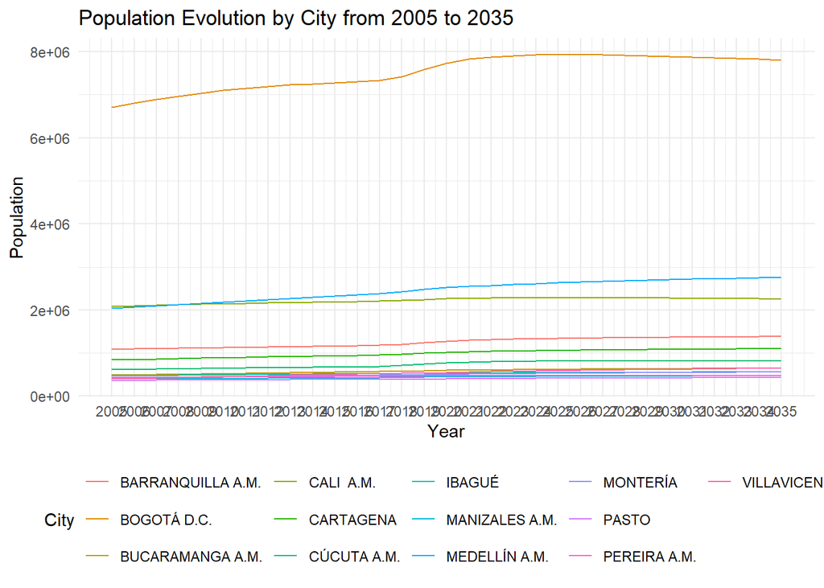

```r
ggplot(joint_data_2005_2035, aes(x = AÑO, y = Población, group = ciudad_am, color = ciudad_am)) +
  geom_line() +
  labs(title = "Population Evolution by City from 2005 to 2035",
       x = "Year",
       y = "Population",
       color = "City") +
  theme_minimal() +
  theme(legend.position = "bottom") +
  scale_x_continuous(breaks = seq(min(joint_data_2005_2035$AÑO), max(joint_data_2005_2035$AÑO), by = 1))  # Adjust the x-axis breaks if needed
```